# Excel analysis

## 5. KPCA

I did KPCA because it may be possible that data is scattered in non linear fashion.

Here I first split data then scaled the data agter that I search best n_componets (this was the itterative process). After getting best n_componets I finally made models on new converted dataset

```python
#splitting data
X = df.drop(['strength','ash','superplastic','coarseagg'], axis=1)

y = df[['strength']]


# scale data
X_scaled = preprocessing.scale(X)
X_scaled = pd.DataFrame(X_scaled, columns=X.columns)

y_scaled = preprocessing.scale(y)
y_scaled = pd.DataFrame(y_scaled, columns=y.columns)
```

```python
#Splitting data
X_train, X_test, y_train, y_test = train_test_split(X_scaled, y_scaled, test_size = 0.2, random_state = 1)
```

```python
# Applying Kernel PCA with kernel=rbf
from sklearn.decomposition import KernelPCA
kpca = KernelPCA(n_components = 4, kernel = 'rbf')
X_train_kpca = kpca.fit_transform(X_train)
X_test_kpca = kpca.transform(X_test)
```

#### Linear regression

```python
regression_model_kpca = LinearRegression()
regression_model_kpca.fit(X_train_kpca, y_train)
```

```
LinearRegression(copy_X=True, fit_intercept=True, n_jobs=1, normalize=False)
```

```python
# Model score - R2 or coeff of determinant
# R^2=1–RSS / TSS

regression_model_kpca.score(X_test_kpca, y_test)
```

```
0.5006004112067515
```

#### SVM

```python
clr_kpca = SVR()
clr_kpca.fit(X_train_kpca , y_train)
```

```
SVR(C=1.0, cache_size=200, coef0=0.0, degree=3, epsilon=0.1, gamma='auto',
  kernel='rbf', max_iter=-1, shrinking=True, tol=0.001, verbose=False)
```

```python
y_pred = clr_kpca.predict(X_test_kpca)
```

```python
clr_kpca.score(X_test_kpca, y_test)
```

```
0.5176017593260456
```

#### Decision tree

```python
regressor_kpca = DecisionTreeRegressor(random_state=1)

regressor_kpca.fit(X_train_kpca , y_train)
```

```
DecisionTreeRegressor(criterion='mse', max_depth=None, max_features=None,
           max_leaf_nodes=None, min_impurity_decrease=0.0,
           min_impurity_split=None, min_samples_leaf=1,
           min_samples_split=2, min_weight_fraction_leaf=0.0,
           presort=False, random_state=1, splitter='best')
```

```python
y_pred = regressor_kpca.predict(X_test_kpca)
```

```python
regressor_kpca.score(X_test_kpca, y_test)
```

```
0.5078471063933663
```

```python
#WHEN I USED KPCA OUR PERFORMANCED IS REDUCED TO A VERY LARGE EXTENT THEREFORE WE WONT USE KPCA. THE COMPONETS HERE WAS 4 DUE TO MAX COMPONETS BE 5 THUS WE HAD TO CHOOSE NUMBER LESS THAN 5
```

#### Using PCA and KPCA our performance is going down to a large extent thus will not use these tech

# 5. Cluster Analysis

As seen in pairplot before, we have high cases of mix of gaussian herefore cluster analysis is very imp Here I started with elbow plot first which showed us number cluster that explain most of the variance. I selected 4,5,6 cluster and saw boxplot if each cluster is seperate or not.

```python
#Import all data
df2=df.iloc[:,0:-1]
df2_scaled=df2.apply(zscore)## Identifying and handling outliers
```

```python
cluster_range = range( 2, 16 )   # expect 3 to four clusters from the pair panel visual inspection hence restricting from 2 to 6
cluster_errors = []
for num_clusters in cluster_range:
  clusters = KMeans( num_clusters, n_init = 5)
  clusters.fit(df2_scaled)
  labels = clusters.labels_
  centroids = clusters.cluster_centers_
  cluster_errors.append( clusters.inertia_ )
clusters_df = pd.DataFrame( { "num_clusters":cluster_range, "cluster_errors": cluster_errors } )
clusters_df[0:15]
```

|  | num_clusters | cluster_errors |
| --- | --- | --- |
| 0 | 2 | 6600.056550 |
| 1 | 3 | 5656.659710 |
| 2 | 4 | 4852.249710 |
| 3 | 5 | 4387.089020 |
| 4 | 6 | 4020.396610 |
| 5 | 7 | 3699.857876 |
| 6 | 8 | 3480.396458 |
| 7 | 9 | 3237.364879 |
| 8 | 10 | 3096.908465 |
| 9 | 11 | 2913.901135 |
| 10 | 12 | 2765.738888 |
| 11 | 13 | 2668.899852 |
| 12 | 14 | 2544.140193 |
| 13 | 15 | 2463.558589 |

```
Text(0.5,1,'Selecting k with the Elbow Method')
```

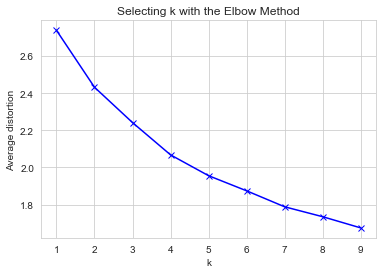

```python
#Finding optimal no. of clusters
from scipy.spatial.distance import cdist
clusters=range(1,10)
meanDistortions=[]

for k in clusters:
    model=KMeans(n_clusters=k)
    model.fit(df2_scaled)
    prediction=model.predict(df2_scaled)
    meanDistortions.append(sum(np.min(cdist(df2_scaled, model.cluster_centers_, 'euclidean'), axis=1)) / df2_scaled.shape[0])


plt.plot(clusters, meanDistortions, 'bx-')
plt.xlabel('k')
plt.ylabel('Average distortion')
plt.title('Selecting k with the Elbow Method')
```

#### Let us first start with K = 5

```python
final_model=KMeans(n_clusters = 5, random_state = 1)
final_model.fit(df2_scaled)
prediction=final_model.predict(df2_scaled)

#Append the prediction
df2["GROUP"] = prediction
df2_scaled["GROUP"] = prediction
print("Groups Assigned : \n")
df2.head()
```

```
Groups Assigned :
```

|  | cement | slag | ash | water | superplastic | coarseagg | fineagg | age | GROUP |
| --- | --- | --- | --- | --- | --- | --- | --- | --- | --- |
| 0 | 141.3 | 212.0 | 0.0 | 203.5 | 0.0 | 971.8 | 748.5 | 28.0 | 3 |
| 1 | 168.9 | 42.2 | 124.3 | 158.3 | 10.8 | 1080.8 | 796.2 | 14.0 | 2 |
| 2 | 250.0 | 0.0 | 95.7 | 187.4 | 5.5 | 956.9 | 861.2 | 28.0 | 2 |
| 3 | 266.0 | 114.0 | 0.0 | 228.0 | 0.0 | 932.0 | 670.0 | 28.0 | 3 |
| 4 | 154.8 | 183.4 | 0.0 | 193.3 | 9.1 | 1047.4 | 696.7 | 28.0 | 3 |

```python
df2_copy = df2_scaled.groupby(['GROUP'])
df2_copy.mean()
```

| GROUP | cement | slag | ash | water | superplastic | coarseagg | fineagg | age |
| --- | --- | --- | --- | --- | --- | --- | --- | --- |
| 0 | -0.349572 | 0.170743 | 1.089059 | 0.469756 | 0.459848 | -1.195414 | -0.330460 | -0.195843 |
| 1 | 1.043348 | 0.491292 | -0.585702 | -1.084580 | 1.127198 | -0.648132 | 0.283765 | 0.016239 |
| 2 | -0.594373 | -0.649406 | 1.112942 | -0.600915 | 0.477840 | 0.600071 | 0.430682 | 0.269815 |
| 3 | -0.720375 | 1.352083 | -0.835298 | 0.655981 | -0.705404 | -0.018105 | -0.346198 | -0.120513 |
| 4 | 0.727034 | -0.786779 | -0.839488 | 0.644205 | -1.049145 | 0.499830 | -0.217052 | -0.105921 |

```
array([[<matplotlib.axes._subplots.AxesSubplot object at 0x0000018F70EF8898>,
      dtype=object)
```

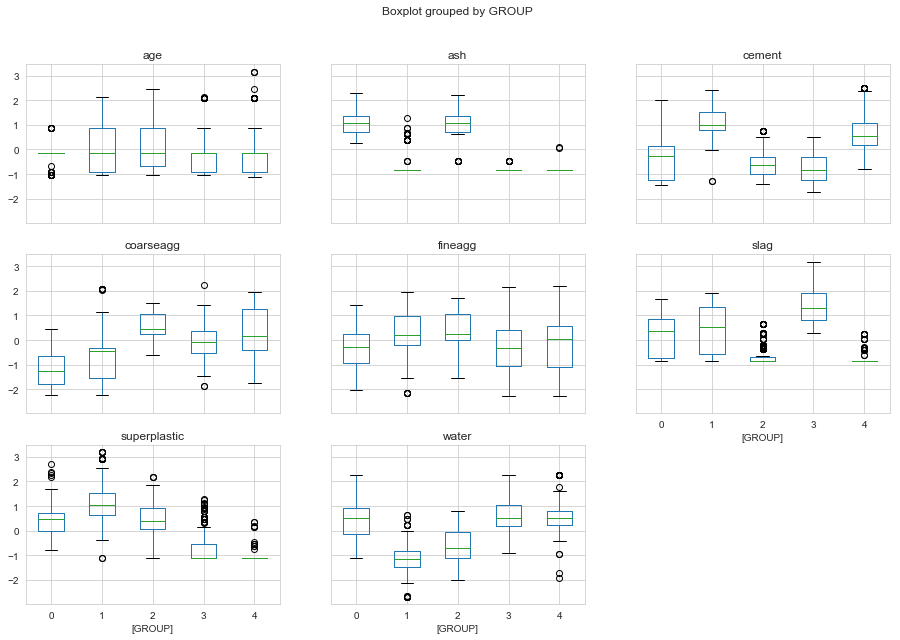

```python
df2_scaled.boxplot(by='GROUP',figsize=(15,10))
```

```python
#No distinct clusters are visble in boxplot try another value of k
```

#### Let us next try with K = 6

```python
# Let us first start with K = 6
final_model=KMeans(n_clusters = 6, random_state = 1)
final_model.fit(df2_scaled)
prediction=final_model.predict(df2_scaled)

#Append the prediction
df2["GROUP"] = prediction
df2_scaled["GROUP"] = prediction
print("Groups Assigned : \n")
df2.head()
```

```
Groups Assigned :
```

|  | cement | slag | ash | water | superplastic | coarseagg | fineagg | age | GROUP |
| --- | --- | --- | --- | --- | --- | --- | --- | --- | --- |
| 0 | 141.3 | 212.0 | 0.0 | 203.5 | 0.0 | 971.8 | 748.5 | 28.0 | 4 |
| 1 | 168.9 | 42.2 | 124.3 | 158.3 | 10.8 | 1080.8 | 796.2 | 14.0 | 3 |
| 2 | 250.0 | 0.0 | 95.7 | 187.4 | 5.5 | 956.9 | 861.2 | 28.0 | 3 |
| 3 | 266.0 | 114.0 | 0.0 | 228.0 | 0.0 | 932.0 | 670.0 | 28.0 | 4 |
| 4 | 154.8 | 183.4 | 0.0 | 193.3 | 9.1 | 1047.4 | 696.7 | 28.0 | 4 |

```python
df2_copy = df2_scaled.groupby(['GROUP'])
df2_copy.mean()
```

| GROUP | cement | slag | ash | water | superplastic | coarseagg | fineagg | age |
| --- | --- | --- | --- | --- | --- | --- | --- | --- |
| 0 | 0.365504 | -0.855246 | -0.847144 | 0.434570 | -1.053484 | 0.527398 | 0.377379 | -0.157682 |
| 1 | 1.043348 | 0.491292 | -0.585702 | -1.084580 | 1.127198 | -0.648132 | 0.283765 | 0.016239 |
| 2 | 1.562901 | -0.495269 | -0.822004 | 1.270211 | -1.042290 | 0.351417 | -1.789233 | 0.032596 |
| 3 | -0.594373 | -0.649406 | 1.112942 | -0.600915 | 0.477840 | 0.600071 | 0.430682 | 0.269815 |
| 4 | -0.759050 | 1.369334 | -0.834920 | 0.605089 | -0.693092 | -0.001879 | -0.284809 | -0.127319 |
| 5 | -0.349572 | 0.170743 | 1.089059 | 0.469756 | 0.459848 | -1.195414 | -0.330460 | -0.195843 |

```
array([[<matplotlib.axes._subplots.AxesSubplot object at 0x0000018F78DE1E80>,
      dtype=object)
```

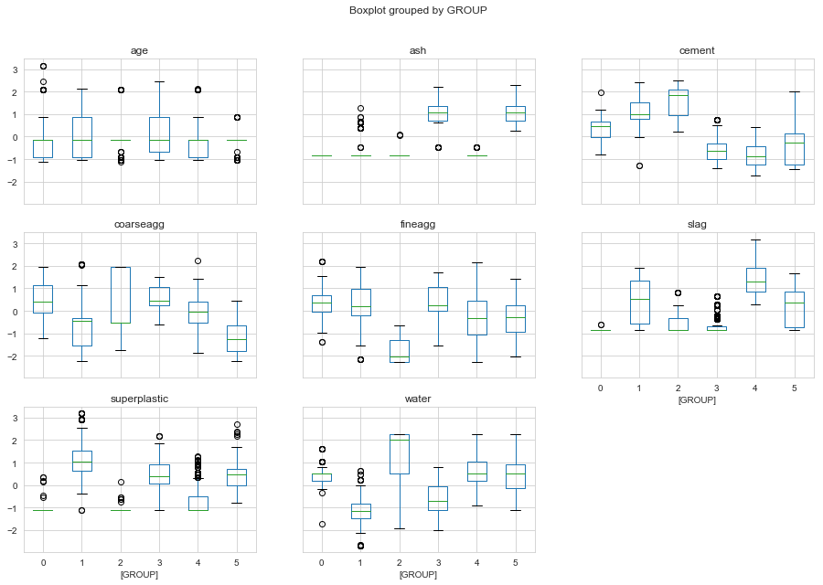

```python
df2_scaled.boxplot(by='GROUP',figsize=(15,10))
```

```python
#No distinct clusters are visible in boxplot try another value of k
```

#### Let us first start with K = 4

```python
final_model=KMeans(n_clusters = 4, random_state = 1)
final_model.fit(df2_scaled)
prediction=final_model.predict(df2_scaled)

#Append the prediction
df2["GROUP"] = prediction
df2_scaled["GROUP"] = prediction
print("Groups Assigned : \n")
df2.head()
```

```
Groups Assigned :
```

|  | cement | slag | ash | water | superplastic | coarseagg | fineagg | age | GROUP |
| --- | --- | --- | --- | --- | --- | --- | --- | --- | --- |
| 0 | 141.3 | 212.0 | 0.0 | 203.5 | 0.0 | 971.8 | 748.5 | 28.0 | 0 |
| 1 | 168.9 | 42.2 | 124.3 | 158.3 | 10.8 | 1080.8 | 796.2 | 14.0 | 2 |
| 2 | 250.0 | 0.0 | 95.7 | 187.4 | 5.5 | 956.9 | 861.2 | 28.0 | 2 |
| 3 | 266.0 | 114.0 | 0.0 | 228.0 | 0.0 | 932.0 | 670.0 | 28.0 | 0 |
| 4 | 154.8 | 183.4 | 0.0 | 193.3 | 9.1 | 1047.4 | 696.7 | 28.0 | 0 |

```python
df2_copy = df2_scaled.groupby(['GROUP'])
df2_copy.mean()
```

| GROUP | cement | slag | ash | water | superplastic | coarseagg | fineagg | age |
| --- | --- | --- | --- | --- | --- | --- | --- | --- |
| 0 | -0.578378 | 0.872811 | -0.028148 | 0.556953 | -0.219887 | -0.509084 | -0.318268 | -0.157218 |
| 1 | 1.043348 | 0.491292 | -0.585702 | -1.084580 | 1.127198 | -0.648132 | 0.283765 | 0.016239 |
| 2 | -0.596889 | -0.652394 | 1.129313 | -0.593130 | 0.499509 | 0.565641 | 0.433440 | 0.262315 |
| 3 | 0.721357 | -0.748265 | -0.839673 | 0.682913 | -1.050158 | 0.475098 | -0.266514 | -0.101134 |

```
array([[<matplotlib.axes._subplots.AxesSubplot object at 0x0000018F77EE6780>,
      dtype=object)
```

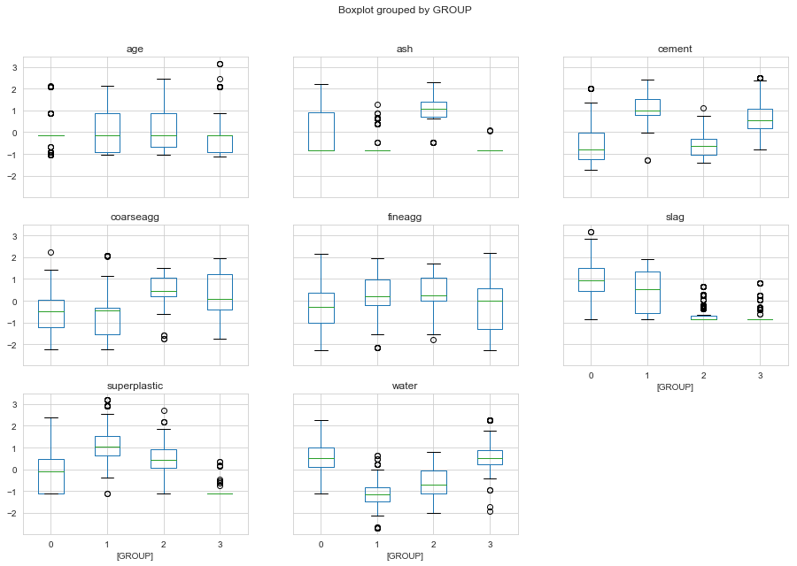

```python
df2_scaled.boxplot(by='GROUP',figsize=(15,10))
```

```python
#Here also no distinct cluster are visible in boxplot
```

#### No distinct clusters are visible at any number of clusters. Looks like the attributes are weak predictors.

#### Thus breaking data into cluster will not give a desired result

# 6. Regularization techniques

Here I used Ridge, lasso and elastic net

### Ridge Regression

```python
from sklearn.linear_model import Ridge
```

```python
ridge_mod = Ridge(alpha=0.5, normalize=True)
ridge_mod.fit(X_train,y_train)
ridge_model_pred = ridge_mod.predict(X_test)

print(ridge_mod.score(X_train, y_train))
print(ridge_mod.score(X_test, y_test))



print("Coefficient Estimate: ", ridge_mod.coef_)
```

```
0.5977315596455892
0.6080337727207549
Coefficient Estimate:  [[ 0.33767551  0.15107293 -0.21272243 -0.10346008  0.33853668]]
```

### Lasso Regression

```python
from sklearn.linear_model import Lasso
```

```python
lasso_mod = Lasso(alpha=0.4, normalize=True)
lasso_mod.fit(X_train,y_train)
lasso_model_pred = lasso_mod.predict(X_test)

print(lasso_mod.score(X_train, y_train))
print(lasso_mod.score(X_test, y_test))



print("Coefficient Estimate: ", lasso_mod.coef_)
```

```
0.0
-0.0022348250338715125
Coefficient Estimate:  [ 0.  0. -0. -0.  0.]
```

```python
#This Shows every columns or features or X's are weak predictors Thus coeff are zeros
```

### Elastic Net Regression

```python
from sklearn.linear_model import ElasticNet
```

```python
en_mod = ElasticNet(alpha=0.02, normalize=True)
en_mod.fit(X_train,y_train)
en_model_pred = en_mod.predict(X_test)

print(en_mod.score(X_train, y_train))
print(en_mod.score(X_test, y_test))

print("Coefficient Estimate: ", en_mod.coef_)
```

```
0.0432615374029901
0.040001104216446086
Coefficient Estimate:  [ 0.02279736  0.         -0.00061948 -0.          0.02087978]
```

# 7. Ensemble Tech

After performing pca, kpca and cluster tech I can conclude that nothing gave desired output thus now trying ensemble technique on columns selected in iteration 2

Here I used bagging, gradrient boost, adaboost, random forest and xtreme forest Further I have used bagging and adaboost boosting in SVR and linear Regression

```python
#Split data set
X = df.drop(['strength','ash','superplastic','coarseagg'], axis=1)

y = df[['strength']]


# scale data
X_scaled = preprocessing.scale(X)
X_scaled = pd.DataFrame(X_scaled, columns=X.columns)

y_scaled = preprocessing.scale(y)
y_scaled = pd.DataFrame(y_scaled, columns=y.columns)
```

```python
#Split dataset
X_train, X_test, y_train, y_test = train_test_split(X_scaled, y_scaled, test_size = 0.2, random_state = 1)
```

```python
from sklearn.ensemble import RandomForestRegressor, GradientBoostingRegressor, BaggingRegressor,AdaBoostRegressor, ExtraTreesRegressor
from sklearn import model_selection
from sklearn.utils import resample
from sklearn.metrics import accuracy_score
from sklearn import metrics
```

## Ensemble on dt

```python
#Gradient boost
gbmTree1 = GradientBoostingRegressor(n_estimators=50, random_state = 1)
gbmTree1.fit(X_train,y_train)
print("gbmTree on training" , gbmTree1.score(X_train, y_train))
print("gbmTree on test data ",gbmTree1.score(X_test,y_test))
```

```
gbmTree on training 0.9018267713100134
gbmTree on test data  0.874213269365002
```

```python
#Adaboost
ada1 = AdaBoostRegressor(n_estimators=50, random_state = 1)
ada1.fit(X_train,y_train)
print("ada on training" , ada1.score(X_train, y_train))
print("ada on test data ",ada1.score(X_test,y_test))
```

```
ada on training 0.805667209682265
ada on test data  0.777002886857119
```

```python
#bagging
bgcl1 = BaggingRegressor(n_estimators=50, random_state = 1)
bgcl1.fit(X_train,y_train)
print("bgcl on train data ", bgcl1.score(X_train,y_train))
print("bgcl on test data ", bgcl1.score(X_test,y_test))
```

```
bgcl on train data  0.977306445696784
bgcl on test data  0.9164663817782749
```

```python
#Random forest
rfTree1 = RandomForestRegressor(n_estimators=50, random_state = 1)
rfTree1.fit(X_train,y_train)
print("rfTree on train data ", rfTree1.score(X_train,y_train))
print("rfTree on test data ", rfTree1.score(X_test,y_test))
```

```
rfTree on train data  0.9773620650851391
rfTree on test data  0.9191125234610917
```

```python
#xtreme forest
xt1 = ExtraTreesRegressor(random_state=1)
xt1.fit(X_train,y_train)
print("rfTree on train data ", xt1.score(X_train,y_train))
print("rfTree on test data ", xt1.score(X_test,y_test))
```

```
rfTree on train data  0.9902251839933607
rfTree on test data  0.9082345126630312
```

## Ensemble on SVM

```python
#BAGGING
bgcl = BaggingRegressor(n_estimators=50, base_estimator=clr)
bgcl = bgcl.fit(X_train,y_train)
print("bgcl on train data ", bgcl.score(X_train,y_train))
print("bgcl on test data ", bgcl.score(X_test,y_test))
```

```
bgcl on train data  0.8809290643909676
bgcl on test data  0.8713358982000604
```

```python
#ADABOOST
ada = AdaBoostRegressor(n_estimators=50,base_estimator=clr)
ada.fit(X_train,y_train)
print("ada on training" , ada.score(X_train, y_train))
print("ada on test data ",ada.score(X_test,y_test))
```

```
ada on training 0.875562144462327
ada on test data  0.8532930313062882
```

## Ensemble on linear regression

```python
#ADABOOST
ada = AdaBoostRegressor(n_estimators=50,base_estimator=regression_model)
ada.fit(X_train,y_train)
print("ada on training" , ada.score(X_train, y_train))
print("ada on test data ",ada.score(X_test,y_test))
```

```
ada on training 0.6787674468612794
ada on test data  0.6831681908024207
```

```python
#BAGGING
bgcl = BaggingRegressor(n_estimators=50, base_estimator=regression_model)
bgcl = bgcl.fit(X_train,y_train)
print("bgcl on train data ", bgcl.score(X_train,y_train))
print("bgcl on test data ", bgcl.score(X_test,y_test))
```

```
bgcl on train data  0.6889055338801802
bgcl on test data  0.6920465026352831
```

#### Random forest is giving best score therfore I am chosing it for furthet improvement

## Ensemble on ensemble

```python
en_en = pd.DataFrame() #starting with empty dataframe
en_en.head()
```

```python
#Calculating prediction and storing in dataframes
q = pd.DataFrame({'bg':bgcl1.predict(X_train)})
w = pd.DataFrame({'rf':rfTree1.predict(X_train)})
e = pd.DataFrame({'xt':xt1.predict(X_train)})
#r = pd.DataFrame({'gb':gbmTree1.predict(X_train)})
```

```python
#Concating above  dataframes to train set
en_en = pd.concat([q,w,e, pd.DataFrame(y_train).reset_index(drop=True)], axis=1)
en_en.columns
```

```
Index(['bg', 'rf', 'xt', 'strength'], dtype='object')
```

```python
en_en.head()
```

|  | bg | rf | xt | strength |
| --- | --- | --- | --- | --- |
| 0 | -0.869567 | -0.861895 | -1.000619 | -1.000619 |
| 1 | 2.124975 | 2.124975 | 2.124975 | 2.124975 |
| 2 | -0.731230 | -0.732116 | -0.653863 | -0.653863 |
| 3 | -0.370247 | -0.369816 | -0.375380 | -0.375380 |
| 4 | -0.010838 | -0.003327 | 0.118702 | 0.118702 |

# Changing column name of target column

```python
en_en.head()
```

|  | bg | rf | xt | strength |
| --- | --- | --- | --- | --- |
| 0 | -0.869567 | -0.861895 | -1.000619 | -1.000619 |
| 1 | 2.124975 | 2.124975 | 2.124975 | 2.124975 |
| 2 | -0.731230 | -0.732116 | -0.653863 | -0.653863 |
| 3 | -0.370247 | -0.369816 | -0.375380 | -0.375380 |
| 4 | -0.010838 | -0.003327 | 0.118702 | 0.118702 |

```python
#Meta regressor
m_reg=SVR()
#m_reg = DecisionTreeClassifier(criterion = "entropy",max_leaf_nodes= 2, min_samples_leaf= 4, min_samples_split= 2,random_state=1)
#m_reg = DecisionTreeClassifier(criterion = "entropy",max_leaf_nodes= 2, min_samples_leaf= 4, min_samples_split= 2,random_state=1)
```

```python
#fitting data similar to X_train and y_train
m_reg.fit(en_en[['bg','rf','xt']], en_en['strength'])
```

```
SVR(C=1.0, cache_size=200, coef0=0.0, degree=3, epsilon=0.1, gamma='auto',
  kernel='rbf', max_iter=-1, shrinking=True, tol=0.001, verbose=False)
```

```python
#For test data
en_test = pd.DataFrame()
```

```python
#Calc predictions and storing in dfs
q1 = pd.DataFrame({'bg':bgcl1.predict(X_test)})
w1 = pd.DataFrame({'rf':rfTree1.predict(X_test)})
e1 = pd.DataFrame({'xt':xt1.predict(X_test)})

print(q1.shape)
```

```
(206, 1)
```

```python
#Concat above dfs
en_test = pd.concat([q1,w1,e1], axis=1)
pred=m_reg.predict(en_test[['bg','rf','xt']])
en_test.columns
```

```
Index(['bg', 'rf', 'xt'], dtype='object')
```

```python
#Concat above dfs into pred columns and make on df i.e en_test
en_test = pd.concat([en_test, pd.DataFrame({'pred':pred}).reset_index(drop=True)], axis=1)
en_test.columns
```

```
Index(['bg', 'rf', 'xt', 'pred'], dtype='object')
```

```python
#Concat above dfs into y_test
en_test = pd.concat([en_test, pd.DataFrame(y_test).reset_index(drop=True)], axis=1)
en_test.columns
```

```
Index(['bg', 'rf', 'xt', 'pred', 'strength'], dtype='object')
```

```python
#predictions
r2_score(en_test['strength'], en_test['pred'])
```

```
0.913293269093252
```

```python
#This tech (Ensemble on ensemble) is also not giving highest score thus i will use random forest for further improvement
```

# 8. Model Tuning

I have used grid search and random search in random forest as it gave best scores

### Grid search

```python
#Split X and y
X = df.drop(['strength','ash','superplastic','coarseagg'], axis=1)
y = df[['strength']]


# scale data
X_scaled = preprocessing.scale(X)
X_scaled = pd.DataFrame(X_scaled, columns=X.columns)

y_scaled = preprocessing.scale(y)
y_scaled = pd.DataFrame(y_scaled, columns=y.columns)
```

```python
#Splitting data
X_train, X_test, y_train, y_test = train_test_split(X_scaled, y_scaled, test_size = 0.2, random_state = 1)
```

```python
#init random forest
rfTree = RandomForestRegressor(n_estimators=50, random_state=1)
```

```python
rfTree.get_params()
```

```
{'bootstrap': True,
 'criterion': 'mse',
 'max_depth': None,
 'max_features': 'auto',
 'max_leaf_nodes': None,
 'min_impurity_decrease': 0.0,
 'min_impurity_split': None,
 'min_samples_leaf': 1,
 'min_samples_split': 2,
 'min_weight_fraction_leaf': 0.0,
 'n_estimators': 50,
 'n_jobs': 1,
 'oob_score': False,
 'random_state': 1,
 'verbose': 0,
 'warm_start': False}
```

```python
param_grid = {
    'bootstrap': [True],
    'max_depth': [5,6,7],
    'max_features': [2, 3,4],
    'min_samples_leaf': [3, 4,5],
    'min_samples_split': [5,10,12],
    'n_estimators': [5,6,7]
}
```

grid_search = GridSearchCV(estimator = rfTree, param_grid = param_grid, cv = 3, n_jobs = 1, verbose = 0, return_train_score=True)

```python
# Fit the grid search to the data
#grid_search.fit(X_train, y_train)


grid_search_cv= GridSearchCV(estimator = rfTree, param_grid = param_grid,
                          cv = 3, n_jobs = 1, verbose = 0, return_train_score=True)
grid_search_cv.fit(X_train, y_train)
```

[output not shown]

[output cut: 1405 more lines]

[output not shown]

```
GridSearchCV(cv=3, error_score='raise',
       estimator=RandomForestRegressor(bootstrap=True, criterion='mse', max_depth=None,
           max_features='auto', max_leaf_nodes=None,
           min_impurity_decrease=0.0, min_impurity_split=None,
           min_samples_leaf=1, min_samples_split=2,
           min_weight_fraction_leaf=0.0, n_estimators=50, n_jobs=1,
           oob_score=False, random_state=1, verbose=0, warm_start=False),
       fit_params=None, iid=True, n_jobs=1,
       param_grid={'bootstrap': [True], 'max_depth': [5, 6, 7], 'max_features': [2, 3, 4], 'min_samples_leaf': [3, 4, 5], 'min_samples_split': [5, 10, 12], 'n_estimators': [5, 6, 7]},
       pre_dispatch='2*n_jobs', refit=True, return_train_score=True,
       scoring=None, verbose=0)
```

```python
grid_search_cv.best_estimator_
```

```
RandomForestRegressor(bootstrap=True, criterion='mse', max_depth=7,
           max_features=4, max_leaf_nodes=None, min_impurity_decrease=0.0,
           min_impurity_split=None, min_samples_leaf=3,
           min_samples_split=5, min_weight_fraction_leaf=0.0,
           n_estimators=7, n_jobs=1, oob_score=False, random_state=1,
           verbose=0, warm_start=False)
```

```python
grid_search_cv.best_params_
```

```
{'bootstrap': True,
 'max_depth': 7,
 'max_features': 4,
 'min_samples_leaf': 3,
 'min_samples_split': 5,
 'n_estimators': 7}
```

```python
best_grid = grid_search_cv.best_estimator_
```

```python
best_grid.score(X_test , y_test)
```

```
0.8462764482238035
```

### Random searchcv

```python
from sklearn.model_selection import RandomizedSearchCV
rfTree = RandomForestRegressor(n_estimators=50, random_state=1)
```

```python
# Number of trees in random forest
n_estimators = [int(x) for x in np.linspace(start = 10 , stop = 15, num = 2)]   # returns evenly spaced 10 numbers
# Number of features to consider at every split
max_features = ['auto', 'log2']
# Maximum number of levels in tree
max_depth = [int(x) for x in np.linspace(5, 10, num = 2)]  # returns evenly spaced numbers can be changed to any
max_depth.append(None)
# Minimum number of samples required to split a node
min_samples_split = [2, 5, 10]
# Minimum number of samples required at each leaf node
min_samples_leaf = [1, 2, 4]
# Method of selecting samples for training each tree
bootstrap = [True, False]

# Create the random grid
random_grid = {'n_estimators': n_estimators,
               'max_features': max_features,
               'max_depth': max_depth,
               'min_samples_split': min_samples_split,
               'min_samples_leaf': min_samples_leaf,
               'bootstrap': bootstrap}

print(random_grid)
```

```
{'n_estimators': [10, 15], 'max_features': ['auto', 'log2'], 'max_depth': [5, 10, None], 'min_samples_split': [2, 5, 10], 'min_samples_leaf': [1, 2, 4], 'bootstrap': [True, False]}
```

```python
# Use the random grid to search for best hyperparameters

# Random search of parameters, using 3 fold cross validation,
# search across 100 different combinations, and use all available cores
rf_random = RandomizedSearchCV(estimator=rfTree, param_distributions=random_grid,
                              n_iter = 5, scoring='neg_mean_absolute_error',
                              cv = 5, verbose=2, random_state=1, n_jobs=-1,
                              return_train_score=True)

# Fit the random search model
rf_random.fit(X_train, y_train);
```

```
Fitting 5 folds for each of 5 candidates, totalling 25 fits
```

```
[Parallel(n_jobs=-1)]: Done  15 out of  25 | elapsed:    4.7s remaining:    3.1s
[Parallel(n_jobs=-1)]: Done  25 out of  25 | elapsed:    4.7s finished
```

```python
rf_random.best_params_
```

```
{'n_estimators': 10,
 'min_samples_split': 2,
 'min_samples_leaf': 2,
 'max_features': 'auto',
 'max_depth': None,
 'bootstrap': True}
```

```python
best_random = rf_random.best_estimator_   # best ensemble model (with optimal combination of hyperparameters)
```

```python
best_random.score(X_test , y_test)
```

```
0.8947836471440285
```

### 95% confidence interval

```python
res = cross_val_score(best_random, X_scaled, y_scaled, cv=10)
print("Average Accuracy: \t {0:.4f}".format(np.mean(res)))
print("Accuracy SD: \t\t {0:.4f}".format(np.std(res)))
```

```
Average Accuracy: 	 0.8900
Accuracy SD: 		 0.0271
```

```python
#for 95% confidence interval
print("range r1 = {0:.3f}".format(np.mean(res)+1.94*(np.std(res))),"    r2 = {0:.3f}".format(np.mean(res)-1.94*(np.std(res))) )
```

```
range r1 = 0.943     r2 = 0.837
```

# CONCLUSION:

*As seen from the start i.e excel analysis the data suffered from outliers and mix of gaussian it was not easy to select appropriate technique also from various techniques it was evident that each attribute is a weak predictors. I have applied various techniques such as clustering, featurization and Regularization but none of them worked, but after applying Ensemble tech I got better results further using random forest I get best score. Also I used random forest for further tuming the model and in production I would use random forest. The confidence interval range for exact 95% is 94.3% to 83.7%*